# Version control

[`Git`]

Thomas De Graaff

August 23, 2016

# Introduction

# Version control *What*

*The modern scientist’s lab notebook*

- Keep track of changes in a project *as they occur*
- Document the changes
- Archive the history in a way that allows to *easily* roll back
- Tell differences with other versions (collaboration) and be able to merge them

# Version control *Why*

- **Sanity**: nothing “committed” is lost
  - just think about GTD principles (or decluttering conform Kondo)
- **Archival**: keep record on when what changed how
- **Collaboration**: work simultaneously with colleagues, properly merge and manage conflicts

Very [neat video](https://www.youtube.com/watch?v=hNENiG7LAnc) exemplifying the concept

# `Git`

# `Git`

Today:

- Set up a new project
- Track changes as you work
- Examine the change history
- Compare different versions
- Restore old versions of a file
- Other tricks to better manage your `git` project

Not today (but you should check it out):

- [Collaboration](http://software-carpentry.org/v5/novice/git/02-collab.html) with `git`
- [Conflicts](http://software-carpentry.org/v5/novice/git/03-conflict.html) in `git`

# Why not, e.g., `Dropbox`?

`Dropbox` allows as well for

- collaboration (if not only with yourself)
- rolling back (see historical versions)

Main differences

- `Git` is `better’ in noting the differences between versions
- `Git` is able to merge differences between versions
  - between you and yourself
  - between you and others

# Unnessarily complex?

Go to `Github Desktop` and

- see your changes in your copy of ERSA-WooW
- commit those changes with a message (done the Markdown assignment!)
- push the **Sync** thingie

# `git` - Requirements & Setup

- Open terminal (`Tools and options` > `Open in Git Shell`)
- Assuming you have `git` installed:

```bash
$ git config --global user.name "Your Name"
$ git config --global user.email "your@email.org"
```

- These are for attribution purposes only, it does not sign you up for any service

# `git` - New project (repository)

Navigate to the folder where you want to create the new project (not ERSA-WooW!) and create the directory, naming it the way you prefer:

```bash
$ cd ..
$ mkdir GreatPaper
$ cd GreatPaper
```

Then start tracking:

```bash
$ git init
```

# `git` - New project (repository) (cnt.)

This will create a hidden folder called `.git`, which will story all the history (although you will never access it directly).

A very common command you will use repeatedly is `status`:

```bash
$ git status

# On branch master
#
# Initial commit
#
nothing to commit (create/copy files and use "git add" to track)
```

# `git` - Work…

Start, for example, with one text file. You can create it from the text editor of your preference, or you can create it using a command line editor, but let us open a new file in `Rstudio`, titled:

```markdown
nobelp_paper.md
```

And start working:

```markdown
The world is flat.
```

# `git` - Work… (cnt.)

Take a break. Save and quit the file. And now check the status of the `git` project:

```bash
$ git status

# On branch master
#
# Initial commit
#
# Untracked files:
#   (use "git add <file>..." to include in what will be committed)
#
#   nobelp_paper.md
nothing added to commit but untracked files present (use "git add" to track)
```

# `git` - … and track your work!

At this point, you want `nobelp_paper.md` to be tracked as you work on it. This does *not* come automatically (like in Dropbox, for example), but you need to explicitly add the file:

```bash
$ git add nobelp_paper.md
```

Now `git` knows it has to keep an eye on the file:

# `git` - … and track your work! (cnt.)

```bash
$ git status

# On branch master
#
# Initial commit
#
# Changes to be committed:
#   (use "git rm --cached <file>..." to unstage)
#
#   new file:   nobelp_paper.md
#
```

To record the file at a given stage, you need to “commit” the changes. Include a (short) message describing the advancement:

```bash
$ git commit -m "Current state of knowledge about Earth"
```

Everything is properly recorded at this point.

# `git` - Why `add` and `commit`?

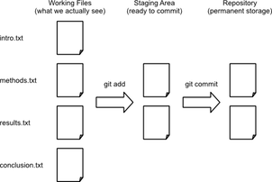

Local spaces

(Source: [Software Carpentry](http://software-carpentry.org/v5/novice/git/img/git-staging-area.png))

# `git` - Why `add` and `commit`? (cnt.)

```bash
$ git status

# On branch master
nothing to commit, working directory clean
```

It means you could keep working, not add, and, when you commit, only the added version will be tracked. Very useful when a project has **many files**!

# `git` - Work, track, work, track…

```markdown
edit nobelp_paper.md
```

```markdown
The world is NOT flat.
```

```bash
$ git status

On branch master
Changes not staged for commit:
  (use "git add <file>..." to update what will be committed)
  (use "git checkout -- <file>..." to discard changes in working directory)

    modified:   nobelp_paper.md

no changes added to commit (use "git add" and/or "git commit -a")
```

# `git` - Work, track, work, track… (cnt.)

Since the file is under tracking already, you can `add` and `commit` in a single shot:

```bash
$ git commit -am "Correcting view about Earth"

[master a643fa0] Correcting view about Earth
 1 file changed, 1 insertion(+), 1 deletion(-)
```

Repeat this process as many times as snapshots you want to record of your project.

# `git` - Examine log

```bash
$ git log

commit b4eeaafcff25d9e6464adbd5083c0202ccce7d90
Author: Thomas de Graaff <t.de.graaff@vu.nl>
Date:   Mon Aug 15 12:09:39 2016 +0200

    Correcting view about Earth

commit 7505fa61d973083d6d33791fc38ad57291c55a92
Author: Thomas de Graaff <t.de.graaff@vu.nl>
Date:   Mon Aug 15 12:08:37 2016 +0200

    Current state of knowledge about Earth
```

# `git` - Examine log (cnt.)

Or a more compressed view…

```bash
$ git log --pretty=oneline

b4eeaafcff25d9e6464adbd5083c0202ccce7d90 Correcting view about Earth
7505fa61d973083d6d33791fc38ad57291c55a92 Current state of knowledge about Earth
```

Or more detailed:

```bash
$ git log --pretty=format:"%h - %a, %ar : %s"

b4eeaaf - %a,  4 minutes ago : Correcting view about Earth
7505fa6 - %a,  5 minutes ago : Current state of knowledge about Earth
```

See more details about tweaking `git log` in [this link](http://www.git-scm.com/book/en/Git-Basics-Viewing-the-Commit-History).

# `git` - Compare versions

Current version from last one tracked (`HEAD`):

```markdown
nobelp_paper.md
```

```markdown
The world is NOT flat at all.
```

```bash
$ git diff

diff --git a/nobelp_paper.md b/nobelp_paper.md
index 5a35641..3215244 100644
--- a/nobelp_paper.md
+++ b/nobelp_paper.md
@@ -1 +1 @@
-The world is NOT flat.
+The world is NOT flat at all.
```

# `git` - Compare versions (cnt.)

You can go back in time n revisions (`HEAD~n`):

```bash
$ git commit -am "Reaffirming myself about Earth's non-flatness"
```

```bash
$ git diff HEAD~2 nobelp_paper.md

diff --git a/nobelp_paper.md b/nobelp_paper.md
index 3fa4573..3215244 100644
--- a/nobelp_paper.md
+++ b/nobelp_paper.mdgit
@@ -1 +1 @@
-The world is flat.
+The world is NOT flat at all.
```

# `git` - Compare versions (ctd.)

Or compare with a specific revision (check log for that):

```bash
$ git diff 7505fa6  nobelp_paper.md

diff --git a/nobelp_paper.md b/nobelp_paper.md
index 3fa4573..3215244 100644
--- a/nobelp_paper.txt
+++ b/nobelp_paper.txt
@@ -1 +1 @@
-The world is flat.
+The world is NOT flat at all.
```

# `git` - Compare versions (cnt.)

Or compare two previous versions:

```bash
$ git diff 7505fa6 b4eeaaf nobelp_paper.md

diff --git a/nobelp_paper.md b/nobelp_paper.md
index 3fa4573..5a35641 100644
--- a/nobelp_paper.md
+++ b/nobelp_paper.md
@@ -1 +1 @@
-The world is flat.
+The world is NOT flat.
```

# `git` - Restore older version

Suppose we delete the file by accident:

```bash
$ rm nobelp_paper.md
```

Bringing the last version back is straightforward:

```bash
$ git checkout HEAD nobelp_paper.md
```

Also works if you decide to go back to a previous version of the file:

```bash
$ git checkout HEAD~2 nobelp_paper.md
```

# `git` - Restore older version (cnt.)

These modifications act as if you had edited the file:

```bash
$ git status

On branch master
Changes to be committed:
  (use "git reset HEAD <file>..." to unstage)

    modified:   nobelp_paper.md
```

So if you want to save the project at that stage again, commit:

```bash
$ git commit -am "Going back to original ideas"
```

# Checkout versus revert

- Checkout allows you to go back in time and restore that version
  - with **all** subsequent changes lost!
- Revert only undoes the changes of that **specific** commit
  - more elegant
  - but quickly conflicts need to be resolved

# `git` - Several files

- `git` tracks “**snapshots**” of the project, rather than changes in particular files.
- Extending this process to several files in the project is straightforward
- The previous workflow favors keeping things organized in **different files**. Although you can manage everything in one master file, having the sections of a paper split into different files makes going back and forth in time much easier and flexible.

# Exercise

- Create a new file with some text and include in the tracking.
- Make a change in the file and commit it.
- Bring the project to a state where `nobelp_paper.md` is in the initial version and the new file is at the latest.

# Exercise (suggested) result

With `RStudio`

```markdown
corollary.md
```

```markdown
I am not really sure about Earth's flatness.
```

```bash
$ git add corollary.md
$ git commit -am "Adding corollary"
```

With `RStudio`

```markdown
corollary.md
```

```markdown
I am not really sure about Earth's flatness, it depends.
```

```bash
$ git commit -am "Introducing uncertainty to corollary"
```

# Exercise (suggested) result (cnt.)

```bash
$ git log --pretty=oneline nobelp_paper.md

25acad2069d72947e5aa2e21ddfe4509205ded88 Going back to original ideas
cfccca975f95ba6588ce07360f4507d5a796b20a Reaffirming myself about Earth's non-flatness
a643fa0ca03291793cb432d799defd0f496b5c9a Correcting view about Earth
6d119ff4a319650bfef06d279b000a56f5fe7759 Current state of knowledge about Eart

$ git checkout 6d119ff4a319650bfef06d279b000a56f5fe7759 nobelp_paper.md
$ git commit -am "Completing exercise"
```

# `git` - Get selective on a project

- A project might have several files (we’ve seen how to deal with that)
- Some of those you might prefer to exclude (or not care to include)
- By default they will not be tracked
- You can create a `.gitignore` file in the root folder listing files to be explicitly excluded from tracking
- With `RStudio` create `.gitignore` file

```bash
$ git add .gitignore
$ git commit -m "Adding ignore file"
```

# `git` - Get selective on a project (cnt.)

```bash
*.aux
```

```bash
$ git status

On branch master
nothing to commit, working directory clean
```